# Lecture 3.2: Computational content analysis

SKOD52 – Strategic Communication:  
Sustainability Communication 2025

nils.holmberg@iko.lu.se

## Course module

1. Sample data collection
2. Computational content analysis
   - Quantitative content analysis
   - Natural language processing
   - Computer vision
3. Communicating sustainability
   - Business intelligence, applications
   - Situation analysis, theory
   - Audience groups, optimization
4. Group assignment, notebook
5. Project seminar

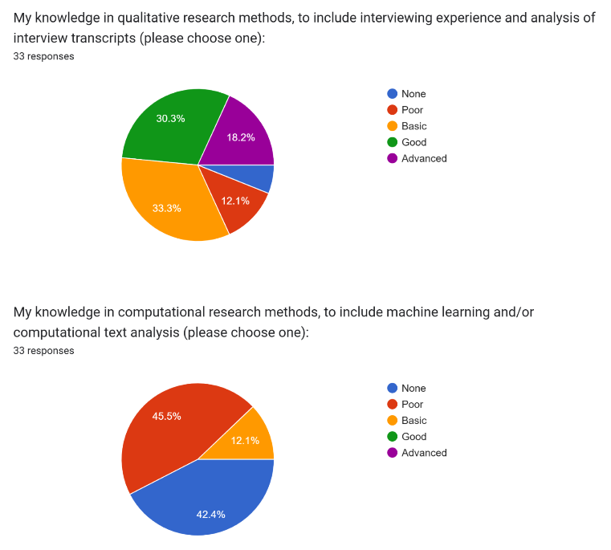

## Data collection

### Workshop, nov 20

- Select one or two [organizational websites](https://www.shell.com/sustainability.html)
- Capture multimodal web page data as 10 pdf
- Put content data on shared google drive
- Use student email google accounts
- Share content dataset within project group
- and nils.holmberg@iko.lu.se before NLP

[figure not shown]

## Computational Content Analysis

### Lecture, nov 24

- Quantitative content analysis (Neuendorf 2017)
  - manifest content features, descriptive
  - latent content, inference
- Natural language processing (Vasiliev 2020)
  - lexical analysis, frequencies,
  - topic modelling, corpus exploration
  - text categorization, e.g. spam mail
  - sentiment analysis
  - text embeddings
- Computer vision (Niebles & Krishna 2017)

## Natural Language Processing

### Workshop, nov 25

- Text as (unstructured) data
- Data cleaning
  - tokenization
  - stopwords
  - lemmatization
- Text data analysis
  - descriptive, inferential
  - quantitative, computational
- Notebook template, [google colab](https://colab.research.google.com/github/cca-cce/osm-comm/blob/main/jnb/skod52_template.ipynb)

[figure not shown]

## Visual Content and Data Visualization

### Lecture, dec 1

- Computer vision
  - Niebles & Krishna (2017)
  - images, videos, infographics etc
  - image classification
  - facial emotion, demographics
  - object detection, localization
  - image embeddings
  - video understanding
- Data visualizations
  - e.g. [Poldrack (2023)](https://statsthinking21.github.io/statsthinking21-python/03-DataVisualization.html)

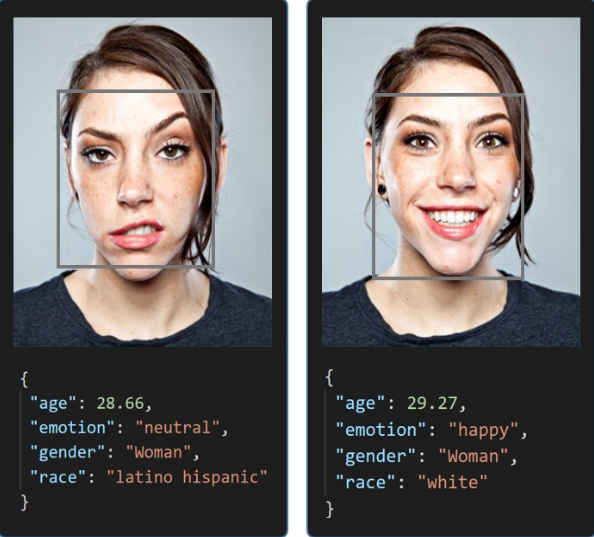

## Communicating sustainability

### Lecture, dec 1

- Cognitive Communication Effects
- Hierarchy of effects models
- Awareness, consideration, action
- Relationship to content features
- Business intelligence, applications
- Situation analysis, strategy
- Audience groups, optimization

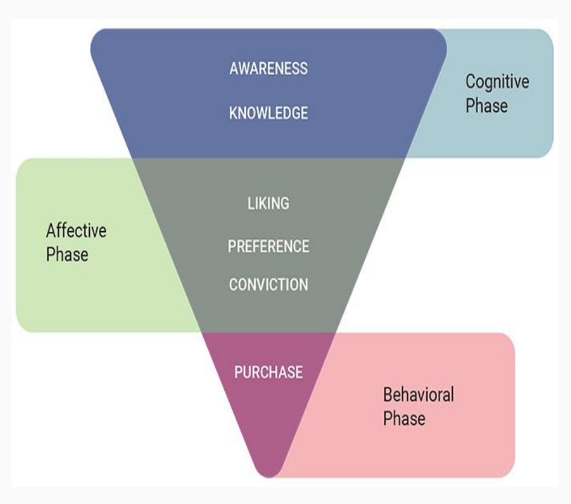

## Computer Vision

### Workshop, dec 2

- Jupyter notebook, Google colab
- Image classification
- Object detection
- Quantitative content analysis
- Extract image features
- Data visualizations
- Data storytelling
- Science communication

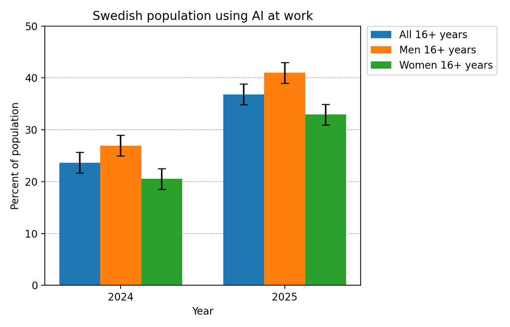

## Group Project, Notebook Handin

### Assignment, dec 16

- Hand in notebook (.ipynb)
- NLP project plus visualizations
- Instructions on canvas
- Workshops and supervision
- [Example notebook](https://github.com/cca-cce/ccass/blob/main/jnb/linkedin_equinor.ipynb)
- Computational content analysis
- Connect to **theoretical** perspectives
- Connect to **practical** cases

## Group Project Presentation

### Seminar, jan 12

- Present jupyter notebook on projector
- Computational content analysis
- Connect to **theoretical** perspectives
- Connect to **practical** cases